# Assignment 3：Verify the Claim of Poverty Change in Philadelphia

Author

Oscar Luo

Published

September 24, 2026

## Part 1: Reconstruct

This report tests claims in Alfred Lubrano’s 2018 [article](https://whyy.org/articles/new-census-figures-on-philly-neighborhoods-show-inequality-high-numbers-of-whites-living-in-poverty/), including a city poverty rate near 26% in 2013–2017 and large increases in several neighborhoods. Because the article does not publish a tract-to-neighborhood crosswalk, I use census tracts and do not attempt the optional neighborhood aggregation.

I use ACS table B17001: `B17001_002` (population below poverty) divided by `B17001_001` (population for whom poverty status is determined). The 2010 and 2017 ACS five-year releases match the article’s 2006–2010 and 2013–2017 periods and provide tract estimates. Because the periods do not overlap, I treat them as independent, although each estimate still summarizes five years.

```r
poverty_2010 <- get_acs(
  geography = "tract",
  variables = c(
    total = "B17001_001",
    below_poverty = "B17001_002"
  ),
  state = "PA",
  county = "Philadelphia",
  year = 2010,
  survey = "acs5",
  output = "wide"
)

poverty_2017 <- get_acs(
  geography = "tract",
  variables = c(
    total = "B17001_001",
    below_poverty = "B17001_002"
  ),
  state = "PA",
  county = "Philadelphia",
  year = 2017,
  survey = "acs5",
  output = "wide"
)
```

## Part 2: Test

### Poverty rates and margins of error

Because the poverty rate is a proportion, I calculate its 90% margin of error with `moe_prop()`.

```r
poverty_2010 <- poverty_2010 %>%
  mutate(
    poverty_rate = below_povertyE / totalE,
    poverty_rate_moe = moe_prop(
      num = below_povertyE,
      denom = totalE,
      moe_num = below_povertyM,
      moe_denom = totalM
    )
  )

poverty_2017 <- poverty_2017 %>%
  mutate(
    poverty_rate = below_povertyE / totalE,
    poverty_rate_moe = moe_prop(
      num = below_povertyE,
      denom = totalE,
      moe_num = below_povertyM,
      moe_denom = totalM
    )
  )
```

### Missing values

First I check 2006–2010 for zero denominators or missing estimates.

```r
missing_2010 <- poverty_2010 %>%
  filter(
    totalE == 0 |
      is.na(poverty_rate) |
      is.na(poverty_rate_moe)
  )

dim(missing_2010)
```

```
[1] 7 8
```

`dim()` reports rows, then columns. The seven rows are tracts with no valid 2006–2010 rate.

The same check for 2013–2017 gives:

```r
missing_2017 <- poverty_2017 %>%
  filter(
    totalE == 0 |
      is.na(poverty_rate) |
      is.na(poverty_rate_moe)
  )

dim(missing_2017)
```

```
[1] 8 8
```

Eight tracts have no valid 2013–2017 rate. In both periods, invalid rates come from zero denominators, so I exclude them rather than treat them as zero. Matching leaves 376 usable tracts.

### Reliability

I calculate CV as `(MOE / 1.645) / poverty rate * 100`. Following Jurjevich et al. (2018), CV below 12% is High confidence, 12–40% is Moderate, and above 40% is Low confidence.

```r
poverty_2010_valid <- poverty_2010 %>%
  filter(
    totalE > 0,
    !is.na(poverty_rate),
    !is.na(poverty_rate_moe)
  ) %>%
  mutate(
    period = "2006–2010",
    poverty_rate_se = poverty_rate_moe / 1.645,
    cv = poverty_rate_se / poverty_rate * 100,
    reliability = case_when(
      cv < 12  ~ "High confidence",
      cv <= 40 ~ "Moderate",
      TRUE     ~ "Low confidence"
    )
  )

poverty_2017_valid <- poverty_2017 %>%
  filter(
    totalE > 0,
    !is.na(poverty_rate),
    !is.na(poverty_rate_moe)
  ) %>%
  mutate(
    period = "2013–2017",
    poverty_rate_se = poverty_rate_moe / 1.645,
    cv = poverty_rate_se / poverty_rate * 100,
    reliability = case_when(
      cv < 12  ~ "High confidence",
      cv <= 40 ~ "Moderate",
      TRUE     ~ "Low confidence"
    )
  )

city_rate_2017 <- sum(poverty_2017_valid$below_povertyE) /
  sum(poverty_2017_valid$totalE)
```

#### Reliability in 2006–2010

```r
poverty_2010_valid %>%
  group_by(reliability) %>%
  summarize(
    n_tracts = n()
  ) %>%
  mutate(
    symbol = case_when(
      reliability == "High confidence" ~ "✓",
      reliability == "Moderate" ~ "△",
      TRUE ~ "!"
    ),
    order = case_when(
      reliability == "High confidence" ~ 1,
      reliability == "Moderate" ~ 2,
      TRUE ~ 3
    )
  ) %>%
  arrange(order) %>%
  select(symbol, reliability, n_tracts) %>%
  gt() %>%
  cols_label(
    symbol = "",
    reliability = "Confidence level",
    n_tracts = "Number of tracts"
  ) %>%
  tab_header(
    title = "Reliability of tract poverty-rate estimates",
    subtitle = "Philadelphia, 2006–2010 ACS five-year estimates"
  ) %>%
  tab_source_note(
    "Source: U.S. Census Bureau ACS via tidycensus. Symbols: ✓ High confidence, △ Moderate, ! Low confidence. Jurjevich et al. (2018) thresholds: CV < 12%, 12–40%, and > 40%."
  )
```

Reliability of tract poverty-rate estimates

Philadelphia, 2006–2010 ACS five-year estimates

|  | Confidence level | Number of tracts |
| --- | --- | --- |
| ✓ | High confidence | 11 |
| △ | Moderate | 321 |
| ! | Low confidence | 45 |

Source: U.S. Census Bureau ACS via tidycensus. Symbols: ✓ High confidence, △ Moderate, ! Low confidence. Jurjevich et al. (2018) thresholds: CV < 12%, 12–40%, and > 40%.

#### Reliability in 2013–2017

```r
poverty_2017_valid %>%
  group_by(reliability) %>%
  summarize(
    n_tracts = n()
  ) %>%
  mutate(
    symbol = case_when(
      reliability == "High confidence" ~ "✓",
      reliability == "Moderate" ~ "△",
      TRUE ~ "!"
    ),
    order = case_when(
      reliability == "High confidence" ~ 1,
      reliability == "Moderate" ~ 2,
      TRUE ~ 3
    )
  ) %>%
  arrange(order) %>%
  select(symbol, reliability, n_tracts) %>%
  gt() %>%
  cols_label(
    symbol = "",
    reliability = "Confidence level",
    n_tracts = "Number of tracts"
  ) %>%
  tab_header(
    title = "Reliability of tract poverty-rate estimates",
    subtitle = "Philadelphia, 2013–2017 ACS five-year estimates"
  ) %>%
  tab_source_note(
    "Source: U.S. Census Bureau ACS via tidycensus. Symbols: ✓ High confidence, △ Moderate, ! Low confidence. Jurjevich et al. (2018) thresholds: CV < 12%, 12–40%, and > 40%."
  )
```

Reliability of tract poverty-rate estimates

Philadelphia, 2013–2017 ACS five-year estimates

|  | Confidence level | Number of tracts |
| --- | --- | --- |
| ✓ | High confidence | 22 |
| △ | Moderate | 332 |
| ! | Low confidence | 22 |

Source: U.S. Census Bureau ACS via tidycensus. Symbols: ✓ High confidence, △ Moderate, ! Low confidence. Jurjevich et al. (2018) thresholds: CV < 12%, 12–40%, and > 40%.

Most estimates are Moderate: 321 in 2006–2010 and 332 in 2013–2017. High-confidence counts are 11 and 22; low-confidence counts are 45 and 22.

### Change between periods

```r
poverty_wide <- bind_rows(
  poverty_2010_valid,
  poverty_2017_valid
) %>%
  select(GEOID, NAME, period, poverty_rate, poverty_rate_moe) %>%
  pivot_wider(
    names_from = period,
    values_from = c(poverty_rate, poverty_rate_moe)
  )

poverty_tested <- poverty_wide %>%
  filter(
    !is.na(`poverty_rate_2006–2010`),
    !is.na(`poverty_rate_2013–2017`)
  ) %>%
  mutate(
    change = `poverty_rate_2013–2017` - `poverty_rate_2006–2010`,
    se_1 = `poverty_rate_moe_2006–2010` / 1.645,
    se_2 = `poverty_rate_moe_2013–2017` / 1.645,
    se_diff = sqrt(se_1^2 + se_2^2),
    moe_diff = se_diff * 1.645,
    z = change / se_diff,
    significant = abs(z) > 1.645,
    result = case_when(
      significant & change > 0 ~ "Significant increase",
      significant & change < 0 ~ "Significant decrease",
      TRUE ~ "Not statistically detectable"
    )
  )

change_counts <- poverty_tested %>%
  count(result)
```

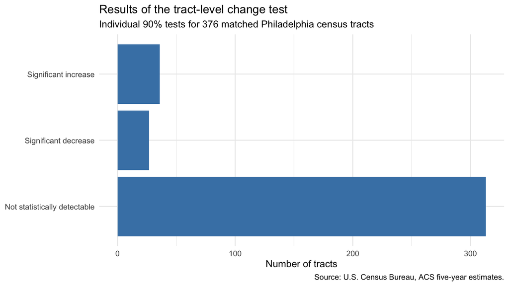

Most Philadelphia tracts did not have a statistically detectable change in poverty rate.

```r
ggplot(change_counts, aes(x = result, y = n)) +
  geom_col(fill = "steelblue") +
  coord_flip() +
  theme_minimal() +
  labs(
    title = "Results of the tract-level change test",
    subtitle = "Individual 90% tests for 376 matched Philadelphia census tracts",
    x = NULL,
    y = "Number of tracts",
    caption = "Source: U.S. Census Bureau, ACS five-year estimates."
  )
```

### Error-bar visualization

The figure shows the 20 largest detectable changes; the counts above include all 376 tracts.

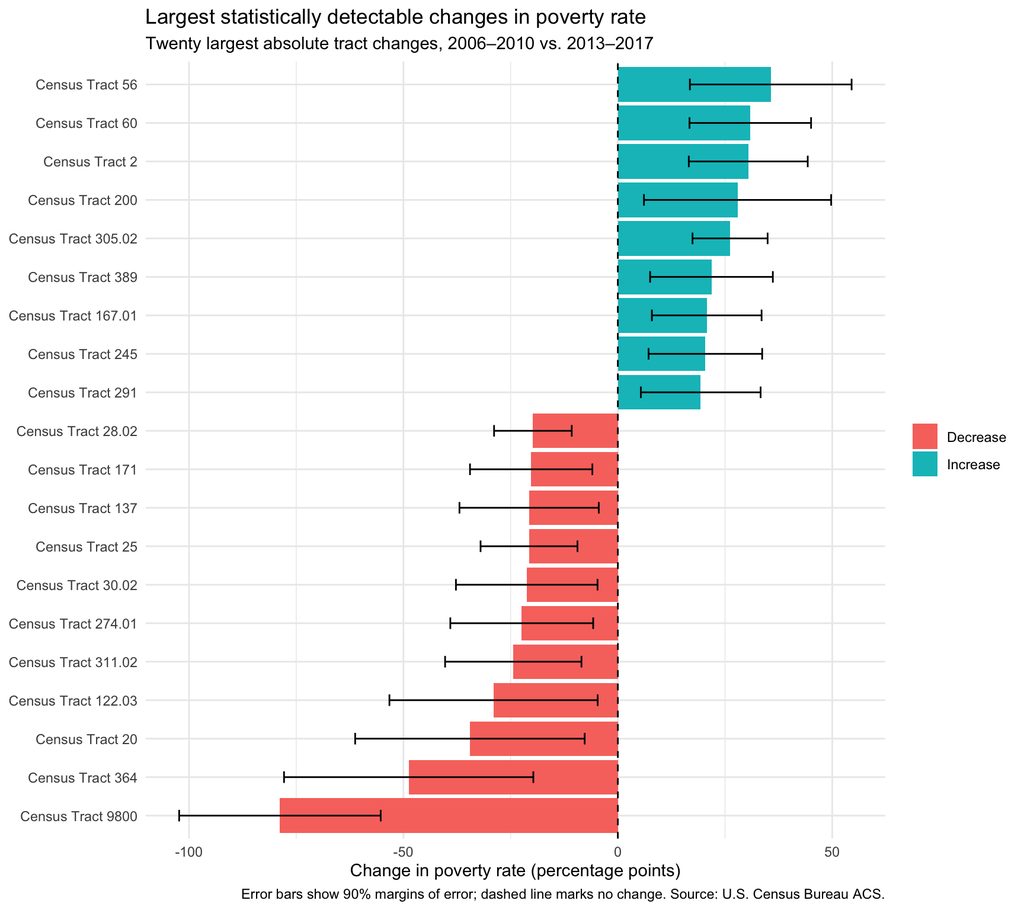

Largest statistically detectable tract-level changes in poverty rates, with 90% margins of error.

```r
change_plot_data <- poverty_tested %>%
  filter(significant) %>%
  arrange(desc(abs(change))) %>%
  slice_head(n = 20) %>%
  mutate(
    NAME = str_remove(NAME, ", Philadelphia County, Pennsylvania"),
    change_pp = change * 100,
    moe_diff_pp = moe_diff * 100,
    direction = case_when(
      change > 0 ~ "Increase",
      TRUE ~ "Decrease"
    )
  )

change_plot_data %>%
  ggplot(aes(x = reorder(NAME, change_pp), y = change_pp)) +
  geom_col(aes(fill = direction)) +
  geom_errorbar(aes(ymin = change_pp - moe_diff_pp,
                    ymax = change_pp + moe_diff_pp), width = 0.3) +
  geom_hline(yintercept = 0, linetype = "dashed") +
  coord_flip() +
  theme_minimal() +
  labs(
    title = "Largest statistically detectable changes in poverty rate",
    subtitle = "Twenty largest absolute tract changes, 2006–2010 vs. 2013–2017",
    x = NULL,
    y = "Change in poverty rate (percentage points)",
    fill = NULL,
    caption = "Error bars show 90% margins of error; dashed line marks no change. Source: U.S. Census Bureau ACS."
  )
```

At 90% confidence, 63 of 376 tracts changed detectably: 36 increased and 27 decreased; 313 showed no detectable change. Poverty change was therefore uneven.

## Part 3: Adjudicate

**Supported.** Combining the tract counts gives a 2013–2017 city poverty rate of 25.8%, consistent with the article’s 26% figure. Poverty also increased in some places: 36 of 376 tracts show detectable increases. **Not supported as a tract-level generalization.** The increase was not widespread: 313 tracts show no detectable change and 27 show decreases.

**Cannot be determined.** The Fairhill, Eastwick, and Holmesburg figures cannot be reproduced because the article does not provide its tract-to-neighborhood crosswalk; the Holmesburg claim also requires race-specific data. Explanations involving opioids, migration, or displacement are beyond what these ACS estimates can establish.

## Part 4: Rewrite

> Philadelphia’s poverty rate was about 25.8% in the 2013–2017 ACS. Change within the city was uneven: of 376 comparable census tracts, 36 had detectable increases, 27 had detectable decreases, and 313 had no detectable change at 90% confidence. Poverty worsened in some places, but not as a widespread tract-level pattern. The reported Fairhill, Eastwick, and Holmesburg figures cannot be reproduced because the article did not publish its tract-to-neighborhood crosswalk. The Holmesburg claim also requires race-specific poverty data.